# Анализ результатов школьного тестирования

Дарья Петрухненко

### 1. Датасет

В таблице представлены оценки по тестированию в американских школах, включая дополнительнительную информацию, такую как пол, этническая пренадлежность, оплата обеда и т.д.

```r
performance <- read_csv('StudentsPerformance.csv')
head(performance)
```

| gender | race/ethnicity | parental level of education | lunch | test preparation course | math score | reading score | writing score |
| --- | --- | --- | --- | --- | --- | --- | --- |
| female | group B | bachelor's degree | standard | none | 72 | 72 | 74 |
| female | group C | some college | standard | completed | 69 | 90 | 88 |
| female | group B | master's degree | standard | none | 90 | 95 | 93 |
| male | group A | associate's degree | free/reduced | none | 47 | 57 | 44 |
| male | group C | some college | standard | none | 76 | 78 | 75 |
| female | group B | associate's degree | standard | none | 71 | 83 | 78 |

Из структуры мы видим, что в таблице представлены три количественные переменные, 4 номинативные и одна ранговая. В распределении количестенных переменных присутствует небольшая отрицательная ассиметрия в связи с верхней границей (100 баллов).

```r
str(performance)
```

```
## spec_tbl_df [1,000 × 8] (S3: spec_tbl_df/tbl_df/tbl/data.frame)
##  $ gender                     : chr [1:1000] "female" "female" "female" "male" ...
##  $ race/ethnicity             : chr [1:1000] "group B" "group C" "group B" "group A" ...
##  $ parental level of education: chr [1:1000] "bachelor's degree" "some college" "master's degree" "associate's degree" ...
##  $ lunch                      : chr [1:1000] "standard" "standard" "standard" "free/reduced" ...
##  $ test preparation course    : chr [1:1000] "none" "completed" "none" "none" ...
##  $ math score                 : num [1:1000] 72 69 90 47 76 71 88 40 64 38 ...
##  $ reading score              : num [1:1000] 72 90 95 57 78 83 95 43 64 60 ...
##  $ writing score              : num [1:1000] 74 88 93 44 75 78 92 39 67 50 ...
##  - attr(*, "spec")=
##   .. cols(
##   ..   gender = col_character(),
##   ..   `race/ethnicity` = col_character(),
##   ..   `parental level of education` = col_character(),
##   ..   lunch = col_character(),
##   ..   `test preparation course` = col_character(),
##   ..   `math score` = col_double(),
##   ..   `reading score` = col_double(),
##   ..   `writing score` = col_double()
##   .. )
```

```r
describe(performance)
```

|  | vars | n | mean | sd | median | trimmed | mad | min | max | range | skew | kurtosis | se |
| --- | --- | --- | --- | --- | --- | --- | --- | --- | --- | --- | --- | --- | --- |
| gender* | 1 | 1000 | 1.482 | 0.4999259 | 1 | 1.47750 | 0.0000 | 1 | 2 | 1 | 0.07193866 | -1.99681865 | 0.01580905 |
| race/ethnicity* | 2 | 1000 | 3.174 | 1.1571789 | 3 | 3.20375 | 1.4826 | 1 | 5 | 4 | -0.14427546 | -0.75377937 | 0.03659321 |
| parental level of education* | 3 | 1000 | 3.486 | 1.8295221 | 3 | 3.48250 | 2.9652 | 1 | 6 | 5 | -0.03005665 | -1.44625488 | 0.05785457 |
| lunch* | 4 | 1000 | 1.645 | 0.4787528 | 2 | 1.68125 | 0.0000 | 1 | 2 | 1 | -0.60513489 | -1.63544421 | 0.01513949 |
| test preparation course* | 5 | 1000 | 1.642 | 0.4796520 | 2 | 1.67750 | 0.0000 | 1 | 2 | 1 | -0.59150381 | -1.65177202 | 0.01516793 |
| math score | 6 | 1000 | 66.089 | 15.1630801 | 66 | 66.37750 | 14.8260 | 0 | 100 | 100 | -0.27809890 | 0.26106523 | 0.47949869 |
| reading score | 7 | 1000 | 69.169 | 14.6001919 | 70 | 69.50125 | 14.8260 | 17 | 100 | 83 | -0.25832772 | -0.07976785 | 0.46169861 |
| writing score | 8 | 1000 | 68.054 | 15.1956570 | 69 | 68.40750 | 16.3086 | 10 | 100 | 90 | -0.28857622 | -0.04511069 | 0.48052887 |

### 2. План исследования

1. Можно предположить, что в среднем баллы по разным предметам будут различаться, т.к. предметы имет разную сложность (например, математика многим дается сложнее других предметов). В связи с этим можно выдвинуть несколько гипотез:
   - Различие средних значений по выборкам (баллы за тест) будут статистически различаться для разных предметов. Проверку можно произвести однофакторным ANOVA с post-hoc t-тестом.
   - Подготовительные курсы также будут давать статистическое различие и будут иметь различное влияние в зависимости от предмета - метод: двухфакторный ANOVA.
2. Уровень образования родителей будет влиять на баллы. Метод: двухфакторный ANOVA.
3. Уровень образования родителей коррелирует с посещением подготовительного курса. Метод: Хи-квадрат.
4. Уровень образования родителей коррелирует со стоимостью обеда (косвенно покажет корреляцию образования/дохода). Метод: Хи-квадрат.
5. Баллы по предметам линейно зависимы, можно построить регрессионную модель. Метод: коэффициент корреляции Пирсона и линейная регрессия.

### 3. Тестирование гипотез

#### Допущения дисперсионного анализа:

- Нормальность распределения признака по группам
- Гомогенность дисперсии

#### 1.1. Сравнение баллов по предметам

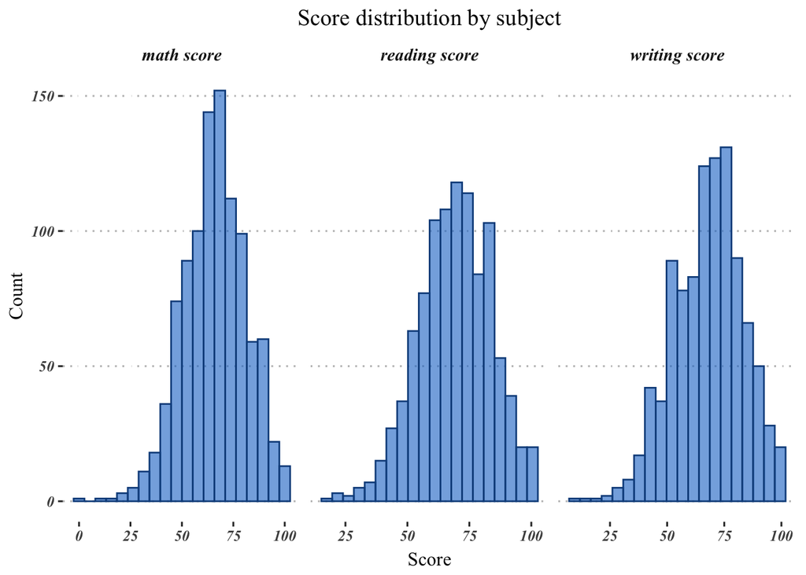

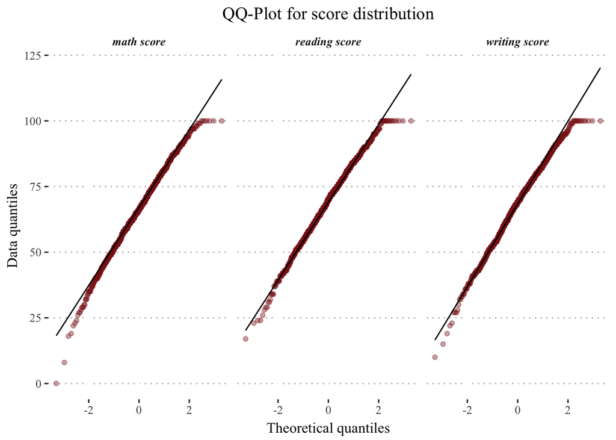

Признак распределен с небольшим отклонением от нормального.

```r
leveneTest(score ~ subject, data = gathered_scores)
```

|  | Df | F value | Pr(>F) |
| --- | --- | --- | --- |
| group | 2 | 0.5552833 | 0.5739687 |
|  | 2997 | NA | NA |

Тест на гомогенность дал p-value > 0.05 - можно принять нулевую гипотезу о гомогенности дисперсий.

```r
aov_by_subject <- aov(score ~ subject, data = gathered_scores)
summary(aov_by_subject)
```

```
##               Df Sum Sq Mean Sq F value   Pr(>F)
## subject        2   4864  2431.8   10.82 2.07e-05 ***
## Residuals   2997 673319   224.7
## ---
## Signif. codes:  0 '***' 0.001 '**' 0.01 '*' 0.05 '.' 0.1 ' ' 1
```

Дисперсионный анализ показал, что как минимум две группы имеют статистически значимое различие.

```r
pairwise.t.test(gathered_scores$score, gathered_scores$subject)
```

```
##
##  Pairwise comparisons using t tests with pooled SD
##
## data:  gathered_scores$score and gathered_scores$subject
##
##               math score reading score
## reading score 1.4e-05    -
## writing score 0.0068     0.0963
##
## P value adjustment method: holm
```

```r
TukeyHSD(aov_by_subject)
```

```
##   Tukey multiple comparisons of means
##     95% family-wise confidence level
##
## Fit: aov(formula = score ~ subject, data = gathered_scores)
##
## $subject
##                               diff       lwr      upr     p adj
## reading score-math score     3.080  1.508189 4.651811 0.0000134
## writing score-math score     1.965  0.393189 3.536811 0.0095217
## writing score-reading score -1.115 -2.686811 0.456811 0.2195724
```

post-hoc сравнения показали, что баллы по математике значимо отличаются от баллов по чтению и письму.

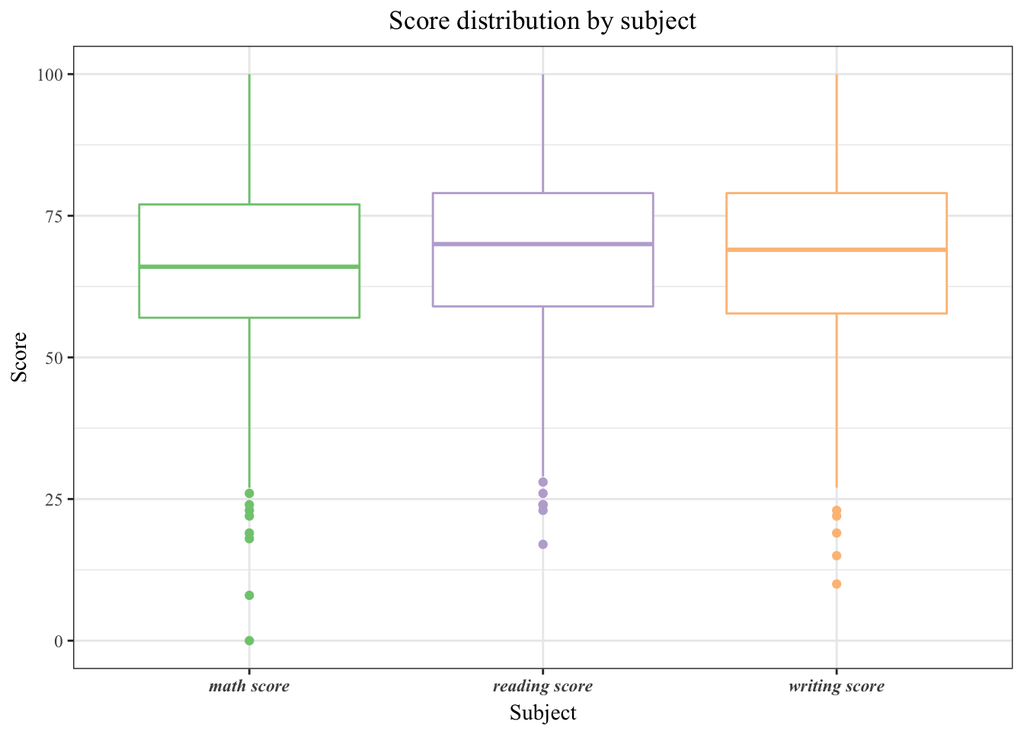

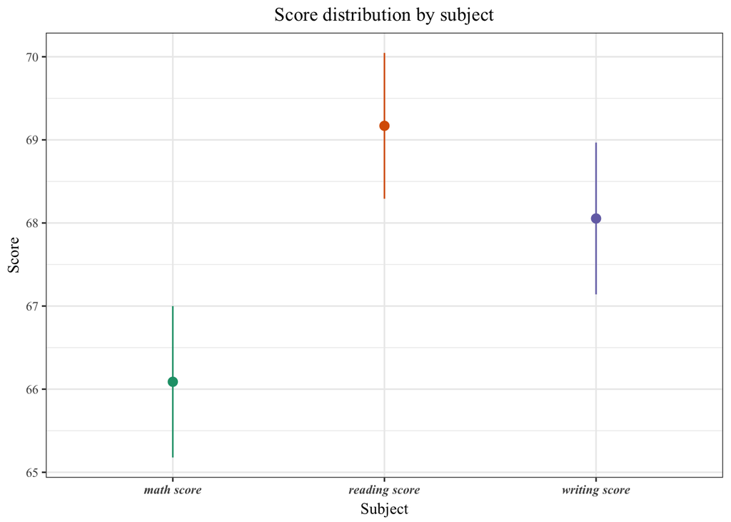

```r
median(performance$`math score`) - median(performance$`writing score`)
```

```
## [1] -3
```

```r
median(performance$`math score`) - median(performance$`reading score`)
```

```
## [1] -4
```

#### 1.2. Сравнение баллов по предметам и посещению подготовительного курса

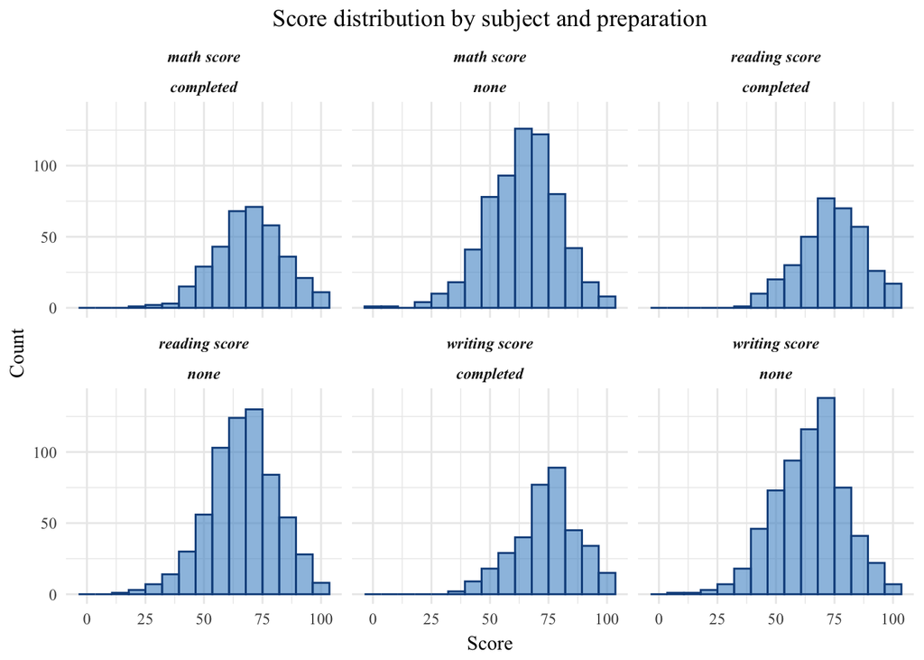

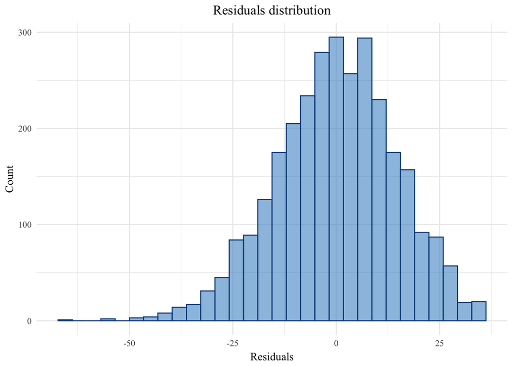

Распределения признака и остатков близки к нормальному.

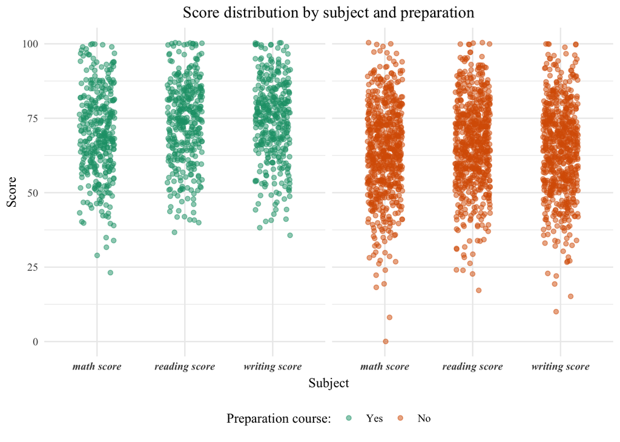

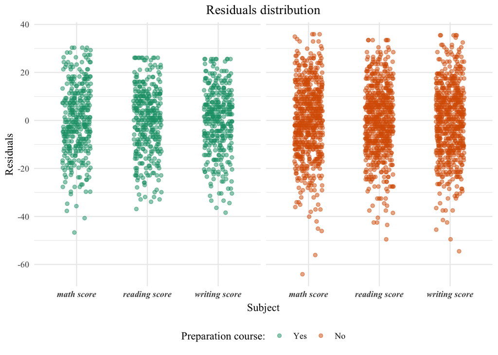

Дисперсия признака и остатков значимо не отличается. Дополнительная проверка статистическими инструментами:

```r
leveneTest(score ~ subject * `test preparation course`,
           data = prep_subject)
```

|  | Df | F value | Pr(>F) |
| --- | --- | --- | --- |
| group | 5 | 1.906354 | 0.08998934 |
|  | 2994 | NA | NA |

```r
aov_by_preparation <- aov(score ~ as.factor(subject) * as.factor(`test preparation course`), data = prep_subject)
summary(aov_by_preparation)
```

```
##                                                           Df Sum Sq Mean Sq
## as.factor(subject)                                         2   4864    2432
## as.factor(`test preparation course`)                       1  40146   40146
## as.factor(subject):as.factor(`test preparation course`)    2   2147    1073
## Residuals                                               2994 631025     211
##                                                         F value   Pr(>F)
## as.factor(subject)                                       11.538 1.02e-05 ***
## as.factor(`test preparation course`)                    190.481  < 2e-16 ***
## as.factor(subject):as.factor(`test preparation course`)   5.093  0.00619 **
## Residuals
## ---
## Signif. codes:  0 '***' 0.001 '**' 0.01 '*' 0.05 '.' 0.1 ' ' 1
```

Результаты дисперсионного анализа говорят о том, что оба фактора и их взаимодействие значимо влияет на изменчивость признака.

```r
TukeyHSD(aov_by_preparation)
```

```
##   Tukey multiple comparisons of means
##     95% family-wise confidence level
##
## Fit: aov(formula = score ~ as.factor(subject) * as.factor(`test preparation course`), data = prep_subject)
##
## $`as.factor(subject)`
##                               diff        lwr       upr     p adj
## reading score-math score     3.080  1.5575919 4.6024081 0.0000065
## writing score-math score     1.965  0.4425919 3.4874081 0.0070409
## writing score-reading score -1.115 -2.6374081 0.4074081 0.1988049
##
## $`as.factor(`test preparation course`)`
##                     diff       lwr       upr p adj
## none-completed -7.630519 -8.714575 -6.546464     0
##
## $`as.factor(subject):as.factor(`test preparation course`)`
##                                                        diff         lwr
## reading score:completed-math score:completed      4.1983240   1.1040924
## writing score:completed-math score:completed      4.7234637   1.6292320
## math score:none-math score:completed             -5.6176491  -8.3483260
## reading score:none-math score:completed          -3.1612628  -5.8919397
## writing score:none-math score:completed          -5.1908578  -7.9215347
## writing score:completed-reading score:completed   0.5251397  -2.5690920
## math score:none-reading score:completed          -9.8159731 -12.5466500
## reading score:none-reading score:completed       -7.3595868 -10.0902637
## writing score:none-reading score:completed       -9.3891819 -12.1198587
## math score:none-writing score:completed         -10.3411128 -13.0717897
## reading score:none-writing score:completed       -7.8847265 -10.6154034
## writing score:none-writing score:completed       -9.9143215 -12.6449984
## reading score:none-math score:none                2.4563863   0.1457754
## writing score:none-math score:none                0.4267913  -1.8838197
## writing score:none-reading score:none            -2.0295950  -4.3402060
##                                                        upr     p adj
## reading score:completed-math score:completed     7.2925557 0.0015576
## writing score:completed-math score:completed     7.8176953 0.0002011
## math score:none-math score:completed            -2.8869722 0.0000001
## reading score:none-math score:completed         -0.4305859 0.0124940
## writing score:none-math score:completed         -2.4601809 0.0000010
## writing score:completed-reading score:completed  3.6193713 0.9967294
## math score:none-reading score:completed         -7.0852962 0.0000000
## reading score:none-reading score:completed      -4.6289100 0.0000000
## writing score:none-reading score:completed      -6.6585050 0.0000000
## math score:none-writing score:completed         -7.6104359 0.0000000
## reading score:none-writing score:completed      -5.1540496 0.0000000
## writing score:none-writing score:completed      -7.1836446 0.0000000
## reading score:none-math score:none               4.7669972 0.0295524
## writing score:none-math score:none               2.7374022 0.9951225
## writing score:none-reading score:none            0.2810159 0.1229276
```

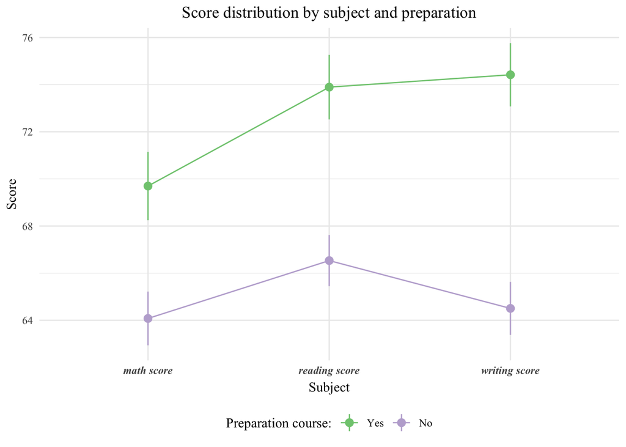

#### 2. Взаимосвязь образования родителей с баллами по предметам

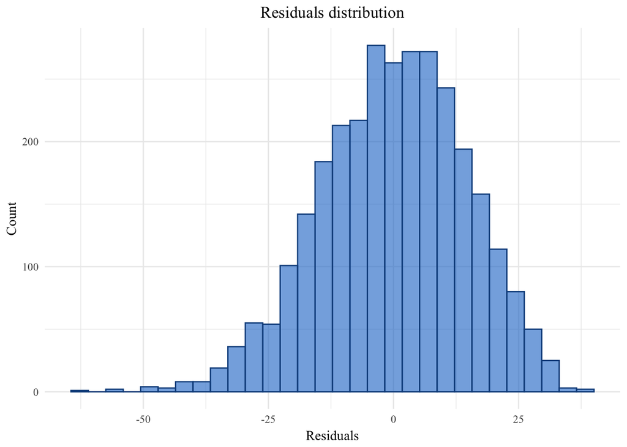

Распределение остатков близко к нормальному.

```r
leveneTest(score ~ subject * `parental level of education`, data = parent_subj)
```

|  | Df | F value | Pr(>F) |
| --- | --- | --- | --- |
| group | 17 | 0.6607411 | 0.8438369 |
|  | 2982 | NA | NA |

Можно принять нулевую гипотезу о гомогенности дисперсий.

```r
summary(aov_parents)
```

```
##                                                               Df Sum Sq Mean Sq
## as.factor(`parental level of education`)                       5  31261    6252
## as.factor(subject)                                             2   4864    2432
## as.factor(`parental level of education`):as.factor(subject)   10   1164     116
## Residuals                                                   2982 640893     215
##                                                             F value   Pr(>F)
## as.factor(`parental level of education`)                     29.091  < 2e-16
## as.factor(subject)                                           11.315 1.27e-05
## as.factor(`parental level of education`):as.factor(subject)   0.542    0.861
## Residuals
##
## as.factor(`parental level of education`)                    ***
## as.factor(subject)                                          ***
## as.factor(`parental level of education`):as.factor(subject)
## Residuals
## ---
## Signif. codes:  0 '***' 0.001 '**' 0.01 '*' 0.05 '.' 0.1 ' ' 1
```

Фактор образования является значимым, а взаимодействие с предметом - незначимо.

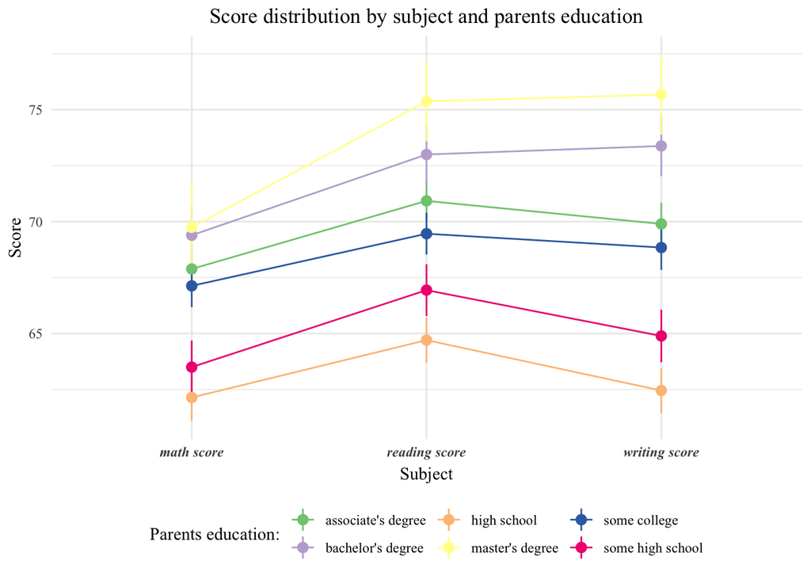

#### 3. Взаимосвязь образования родителей и посещения подготовительного курса

Так как оба фактора оказались значимыми, можно проверить нет ли между ними корреляции.

```r
education_prep_matrix
```

```
##                    completed none
## associate's degree        82  140
## bachelor's degree         46   72
## high school               56  140
## master's degree           20   39
## some college              77  149
## some high school          77  102
```

```r
chisq.test(education_prep_matrix)
```

```
##
##  Pearson's Chi-squared test
##
## data:  education_prep_matrix
## X-squared = 9.5441, df = 5, p-value = 0.08923
```

P-value > 0.05, значит, мы не можем отвергнуть нулевую гипотезу о том, что взаимосвязи между двумя переменными нет.

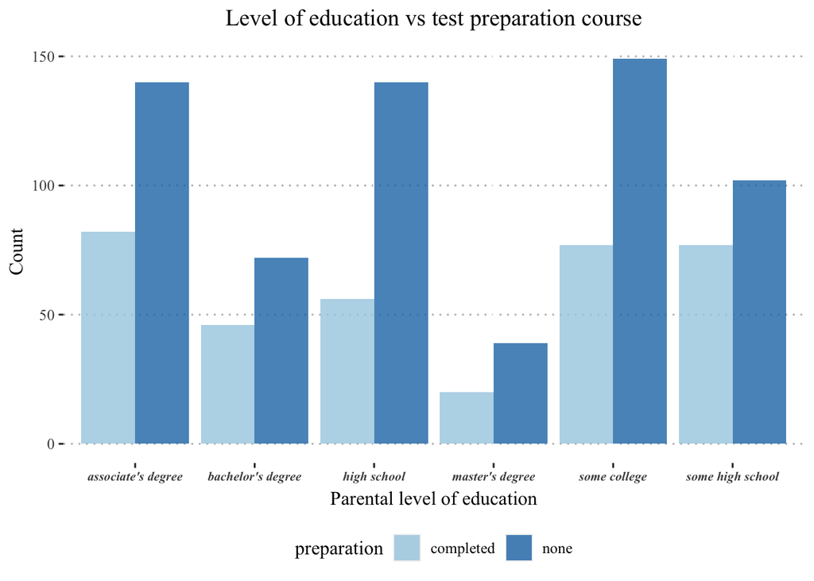

#### 4. Взаимосвязь образования и дохода родителей

Мы можем также проверить взаимосвязь уровня образования родителей и то, как они платят за обед, что может косвенно показать взаимосвязь между образованием и уровнем дохода.

```r
education_lunch_matrix
```

```
##                    free/reduced standard
## associate's degree           77      145
## bachelor's degree            44       74
## high school                  70      126
## master's degree              24       35
## some college                 79      147
## some high school             61      118
```

```r
chisq.test(education_lunch_matrix)
```

```
##
##  Pearson's Chi-squared test
##
## data:  education_lunch_matrix
## X-squared = 1.1113, df = 5, p-value = 0.9531
```

Значение p-value близко к единице, скорее всего, между нашими переменными нет никакой корреляции.

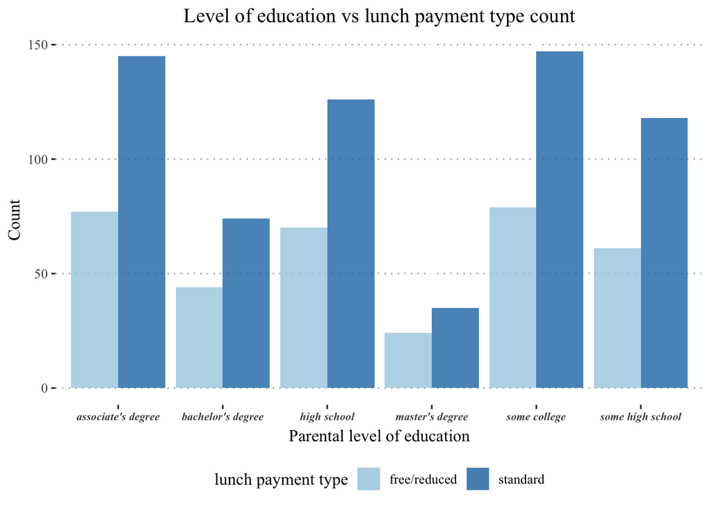

#### 5. Линейная зависимость баллов по разным предметам

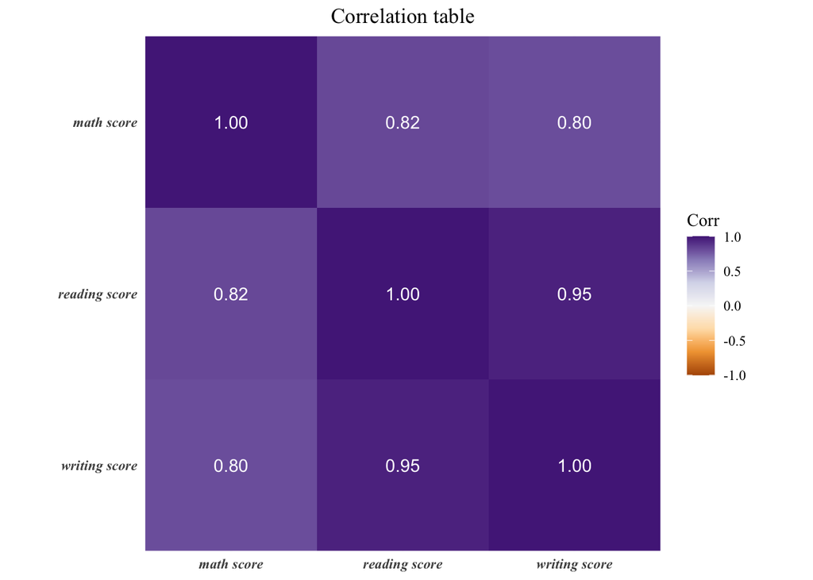

Как и ожидалось, баллы сильно коррелируют. Можно построить регрессионную модель с одним предиктором.

```r
reading_writing_m <- lm(`reading score` ~ `writing score`, data = performance)
summary(reading_writing_m)
```

```
##
## Call:
## lm(formula = `reading score` ~ `writing score`, data = performance)
##
## Residuals:
##      Min       1Q   Median       3Q      Max
## -14.6226  -2.9554   0.1352   3.0399  11.4602
##
## Coefficients:
##                 Estimate Std. Error t value Pr(>|t|)
## (Intercept)      6.75051    0.63175   10.69   <2e-16 ***
## `writing score`  0.91719    0.00906  101.23   <2e-16 ***
## ---
## Signif. codes:  0 '***' 0.001 '**' 0.01 '*' 0.05 '.' 0.1 ' ' 1
##
## Residual standard error: 4.352 on 998 degrees of freedom
## Multiple R-squared:  0.9113, Adjusted R-squared:  0.9112
## F-statistic: 1.025e+04 on 1 and 998 DF,  p-value: < 2.2e-16
```

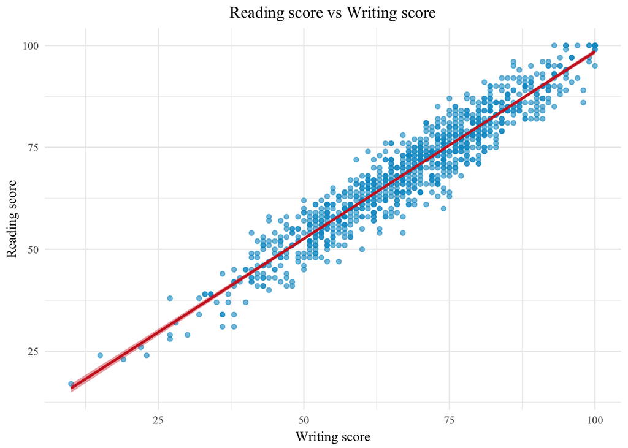

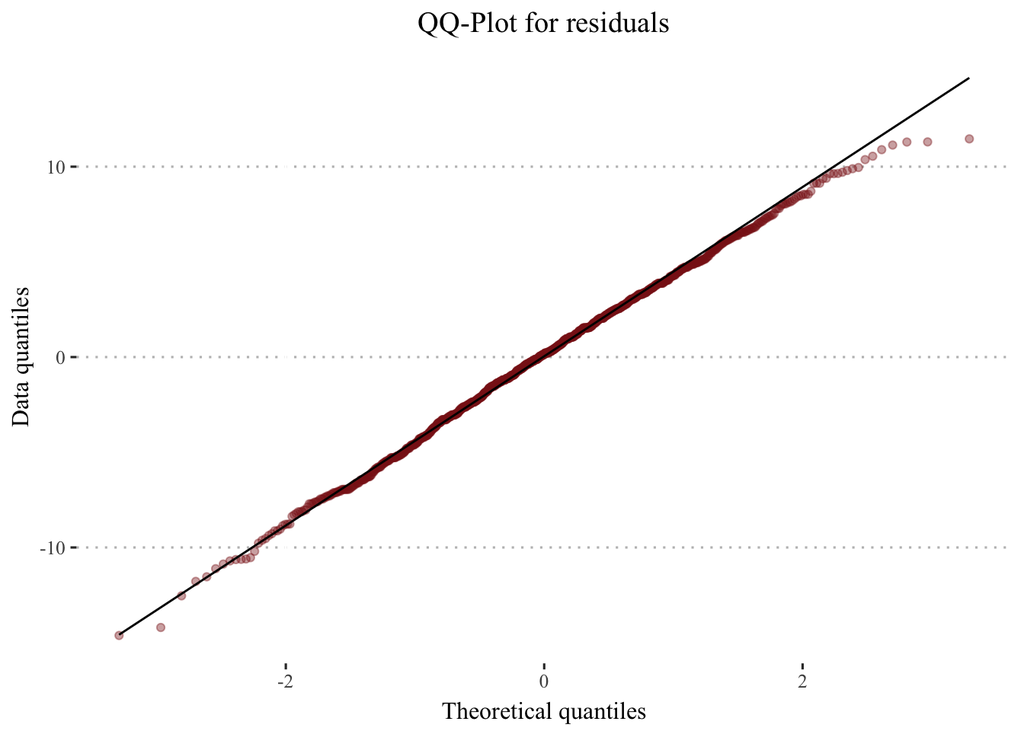

#### Вывод

| parental level of education | lunch | test preparation course | mean score | median score | sd |
| --- | --- | --- | --- | --- | --- |
| master's degree | standard | completed | 82.62500 | 85.0 | 12.15413 |
| some college | standard | completed | 78.88235 | 79.0 | 11.03281 |
| bachelor's degree | standard | completed | 78.66667 | 79.0 | 12.64788 |
| associate's degree | standard | completed | 76.71069 | 78.0 | 12.40322 |
| master's degree | standard | none | 76.69136 | 78.0 | 12.48063 |
| bachelor's degree | standard | none | 72.34074 | 72.0 | 13.96059 |
| master's degree | free/reduced | completed | 72.11111 | 73.5 | 14.96239 |
| bachelor's degree | free/reduced | completed | 72.09804 | 74.0 | 16.06394 |
| some high school | standard | completed | 71.97531 | 74.0 | 13.38858 |
| associate's degree | free/reduced | completed | 71.70115 | 73.0 | 14.45612 |

[output cut: 14 more lines]